# Executive Summary

1. Across all available metrics of success, Spotify-created playlists are much more successful than nearly all user-created playlists.
2. All considered easures of success are highly correlated.
3. The number of tracks is the most important predictor of short-term and long-term playlist success, with longer playlists tending to be more successful.
4. For Spotify-created playlists, having greater musical diversity (as measured by tracks per album and tracks per artist) is associated with increased success. This effect is present for the user-created playlists, but is less pronounced.
5. Greater musical diversity is more important for a playlist's long-term staying power than for short-term success.
6. For Spotify-created playlists, the primary genres of 'dance & house' and 'pop' are associated with both short-term and long-term success.
7. The most success-inducing genres for Spotify-created and user-created vary considerably. For user-created playlists, "Children's", "Latin" and "Traditional" increase both short- and long-term success.

# Outline

1. Explore massive differences in playlist success between the Spotify-created and user-created playlists.
2. Establish the substantial correlation between each of the measures of success across both Spotify-created and user-created playlists will next be discussed. A principal components analysis will be performed.
3. Briefly present the distribution of the predictors of success, including both the numeric (number of tracks, tracks per artist and tracks per album) as well as the categorical (mood and genre).
4. Fit gradient boosting models to predict measures of both short-term and long-term success, stratifying by Spotify-created and user-created playlists. Use SHAP values to assess the inferential implications of the models.
5. The Appendix contains a number of other subanalyses and assumption checks.

# Brief Data Introduction

- The data consists of 403,366 distinct playlists, with 314,899 distinct playlist creators.
- Of the creators with more than one playlist, Spotify itself has the most, with 399.
- The data is composed of only playlists from US creators, and thus extrapolating any of these analyses to other countries is likely unwarranted or should be done with great caution.
- The data consists of a number of potential metrics of playlist success, including measures of total users and streams today, over the past week, month, and over the past two months.
- Each playlist is categorized by its top three genres and top three moods. There are 26 genres and 27 moods under consideration.

# Comparing Spotify-Created and User-Created Playlists

- There are two Spotify-created playlists that constitute extreme outliers across each of the potential outcome variables, which have more than four times as many $>30$ second streams in the past month as the nearest competitor. For the purposes of plotting, these playlists will be removed.
- Even after removing the two most successful Spotify-created playlists, there is still a wide gulf between the Spotify-created and user-created playlists.

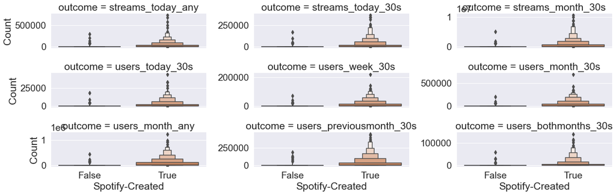

# Exploration of Potential Outcomes

- Amongst the user-created playlists, we see that the minimum correlation between any of the outcomes is 0.78.
- Weakest correlation is between measures of short- and long-term success.

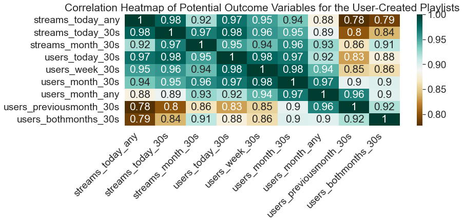

- Amongst the Spotify-created playlists, the potential outcomes are even more highly correlated, with the smallest correlation being 0.91.
- The Spotify-created playlists exhibit a similar general pattern as the user-created in that the weakest correlation is between the long-term and short-term measures of success.

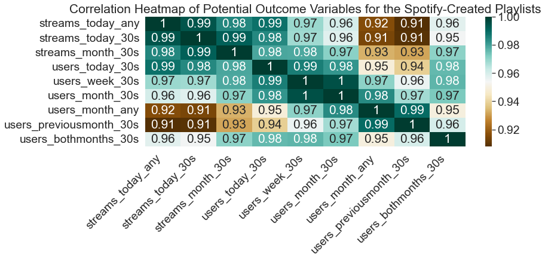

## Principal Components Analysis of Potential Outcomes

- We use a Principal Components Analysis (PCA) to address the degree to which the information in the nine potential outcomes can be reduced to one or a few factors.
- We will show results for the User-Created playlists. The Spotify-created playlist results are similar and can be found in the Appendix.
- 92% of the variation is explained by the first component and an additional 5% is explained by the second component.

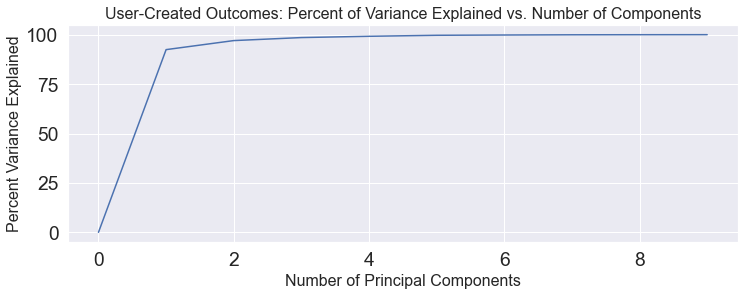

- The plot below presents the loadings for each of the first two principal components.
- The first component loads nearly equally across each of the 9 potential outcomes.
- The second component loads negatively on the long-term measures of success and positively on total streams today.

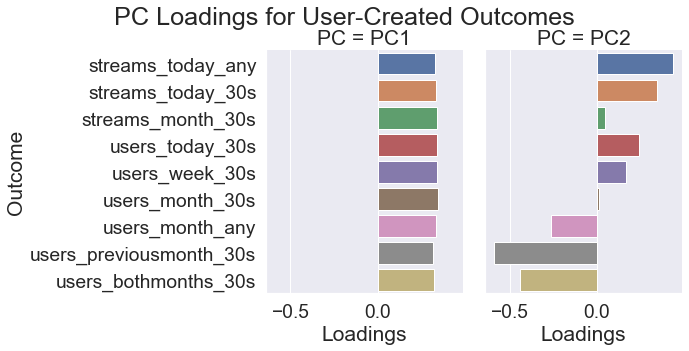

## Exploration of Predictors of Interest

- We will briefly describe the distribution of the numeric predictors (number of tracks, artists and albums) and the categorical predictors (genre and mood).
- We create inverse measures of "musical diversity" as measured by number of tracks per artist and number of tracks per album.
- We drew a random sample of user-created playlists for the plots below in order for them not to visually swamp the Spotify-created playlists.
- Spotify-created playlists exhibit a bit more artist and album diversity than the user-created playlists, but the difference is miniscule compared to the outcome variables.

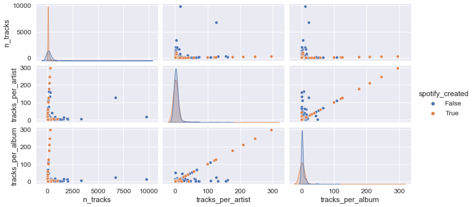

- We now turn our attention to describing the categorical predictors: genre and mood.
- In results now shown, the distribution of genre and mood are similar for user-created and Spotify-created playlists, so we combine them in the plots below.

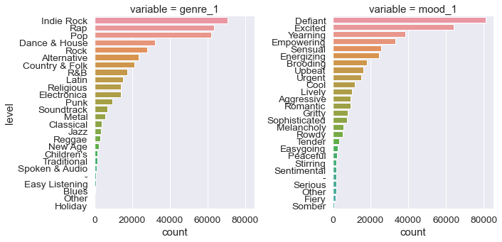

# Predicting Playlist Success

- We now seek to predict playlist success as measured by the number of users with stream greater than 30 seconds today.
- Separate models are fit for the user-created and Spotify-created playlists.
- For sake of brevity, we leave models predicting number of users with a stream in the current and previous months for the Appendix.
- All modeling results presented here should be taken as hypothesis-generating rather than hypothesis-confirming. This is fundamentally a data-mining exercise rather than a testing of well-defined hypotheses defined prior to the construction of models.

## The Modeling Process

- Train a lightgbm gradient boosting model using tenfold cross validation (CV).
- Use early stopping to avoid overfitting and prevent wasted time and compute resources.
- Use the Huber loss function to reduce the effect of the extreme outliers present in our data.
- Based on best number of trees from CV, refit model using all available data.
- We use SHAP values to draw inference from the models.
  1. Create plots of the most important predictors ranked by mean absolute SHAP values.
  2. For genre and mood, create plots that highlight which levels of the variable are related to higher and lower success.
- Deriving measures of inferential uncertainty from gradient boosting models can be challenging. Thus, we also fit a robust M-estimation linear regression with a Huber loss function (results in Appendix).

## Spotify-Created Playlists: Modeling Results for Number of Users Today

- Amongst the Spotify-created playlists, the most important variable predicting success is the number of tracks, followed by the primary mood, tracks per album and tracks per artist.
- Playlists with more tracks tend to have more users today.
- Increasing the musical diversity of a playlist tends to increase playlist success as measured by number of users today.

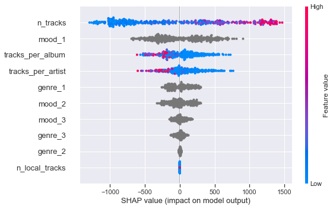

### Spotify-Created Playlists: Genre and Mood Effects

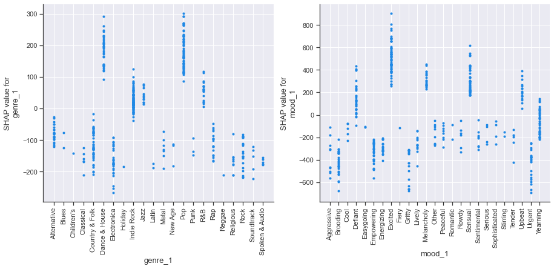

## User-Created Playlists: Modeling Results for Number of Users Today

- Increasing number of tracks is also associated with increased number of users today.
- Genre appears relatively more important than in the Spotify playlists, with the most successful genres being "Children's", "Latin" and "Traditional".
- In a robust linear regression model, each of these genres are found to be significantly more successful than genre = "-".

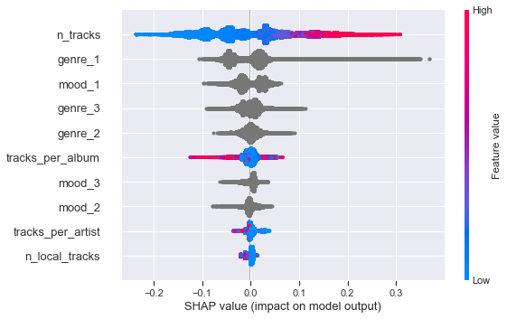

### User-Created Playlists: Genre and Mood Effects

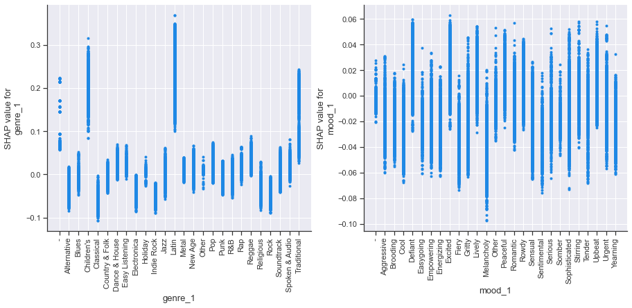

# Appendix

## Spotify-Created Playlists: Modeling Results for Number of Users in Current and Previous Month

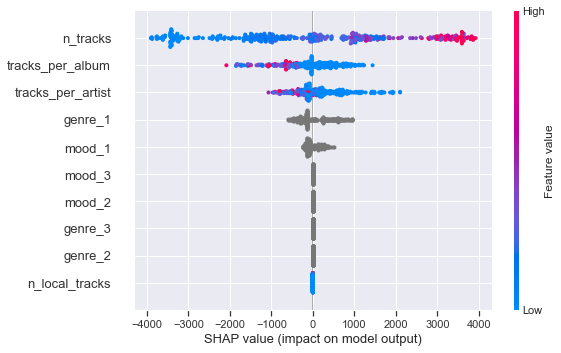

## Spotify-Created Playlists: Modeling Results for Number of Users in Current and Previous Month

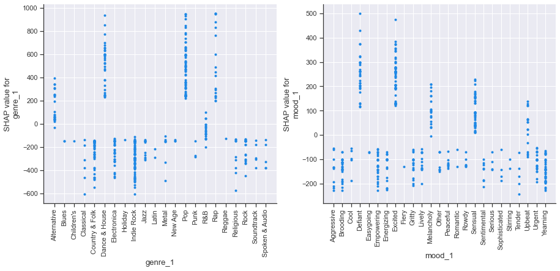

## User-Created Playlists: Modeling Results for Number of Users in Current and Previous Month

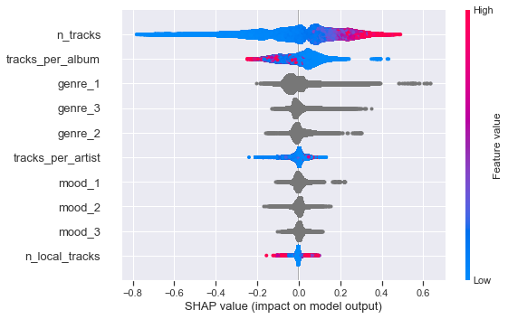

## User-Created Playlists: Modeling Results for Number of Users in Current and Previous Month

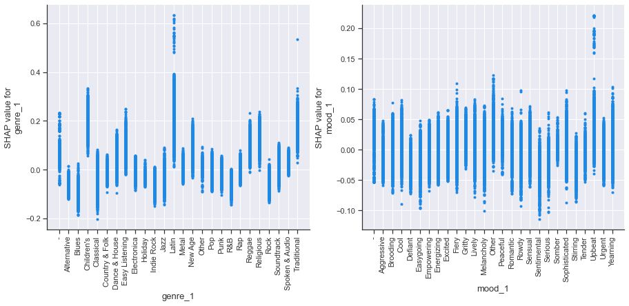

## Assumptions:

1. This is a random sample of playlists. If this a biased sample, then any generalizations that we make from the data is likely to be meaningfully inaccurate.
2. Spotify treats each user-created playlist equally in terms of promotion. For examples, if the Spotify algorithms were promoting some genres above others at the time this data was collected, then we are unlikely to get a good read on how genre affects listenership.
3. (a) Spotify treats its own playlists differently than the non-Spotify playlists. If this assumption is correct, then it is likely that Spotify playlists are not particularly comparable to non-Spotify playlists.  
   (b) Spotify treats its own playlists equally with each other. Thus, an analysis with only Spotify playlists should be okay.
4. Each playlist included in the dataset has existed for at least two months. This ensures that the monthly average users in the previous month variable is not biased by how long the playlist has existed.
5. The Spotify algorithms do not amplify small variations in success. If playlist A was slightly more successful than Playlist B two months ago under 'fair' algorithmic treatment, then the algorithms will not amplify playlist A over playlist B, and thus widen the gulf between the success of the two playlists.
6. For the categorical variables, genre_1-genre_3 and mood_1-mood_3, when the value is '-' this is not a missing value, but is instead imparting the information that the given playlist does not easily fit into the predefined genre and mood types.

## PCA Analysis of Outcomes for Spotify-Created Playlists

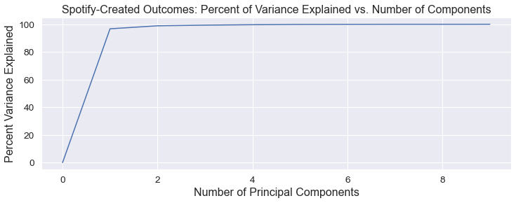

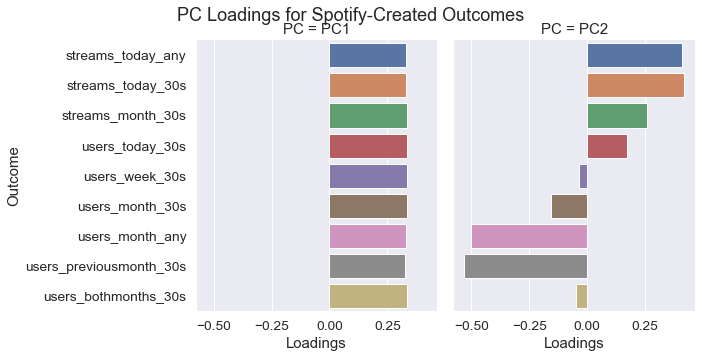

## Plots of Distribution of Secondary and Tertiary Genre and Mood

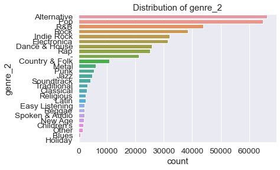

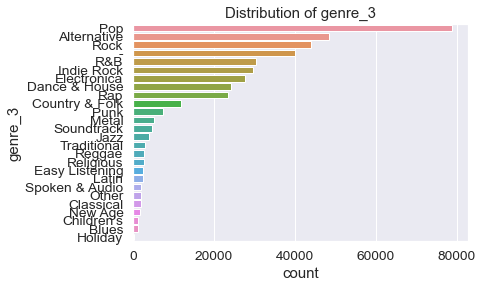

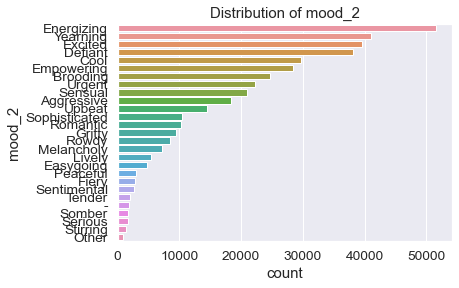

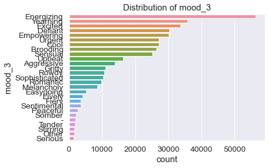

## Robust Linear Regression Model Results

### RLM Model for Spotify-Created Playlists, Outcome = Users Today

```
                           Results: Robust linear model
==================================================================================
Model:                       RLM                      Df Residuals:         351
Dependent Variable:          users_today_30s          Norm:                 HuberT
Date:                        2022-02-25 12:28         Scale Est.:           mad
No. Observations:            399                      Cov. Type:            H1
Df Model:                    47                       Scale:                1289.6
----------------------------------------------------------------------------------
                            Coef.     Std.Err.    z    P>|z|    [0.025     0.975]
----------------------------------------------------------------------------------
Intercept                   592.5850  210.9870  2.8086 0.0050   179.0581 1006.1119
genre_1[T.Alternative]      321.4248  387.0639  0.8304 0.4063  -437.2066 1080.0561
genre_1[T.Blues]           1730.9971 1164.6920  1.4862 0.1372  -551.7574 4013.7515
genre_1[T.Children's]      -445.0210 1603.4611 -0.2775 0.7814 -3587.7470 2697.7050
genre_1[T.Classical]       1301.9412 1010.0657  1.2890 0.1974  -677.7513 3281.6336
genre_1[T.Country & Folk]  -169.5201  365.2716 -0.4641 0.6426  -885.4392  546.3991
genre_1[T.Dance & House]    660.8945  377.2358  1.7519 0.0798   -78.4740 1400.2630
genre_1[T.Easy Listening]    -0.0000    0.0000 -0.5453 0.5855    -0.0000    0.0000
genre_1[T.Electronica]     -603.0586  405.2874 -1.4880 0.1368 -1397.4072  191.2900
genre_1[T.Holiday]         -199.2876 1612.9078 -0.1236 0.9017 -3360.5288 2961.9536
genre_1[T.Indie Rock]       266.7984  283.7900  0.9401 0.3472  -289.4198  823.0166
genre_1[T.Jazz]            -360.3224  556.3045 -0.6477 0.5172 -1450.6592  730.0144
genre_1[T.Latin]             -5.5204 1156.6357 -0.0048 0.9962 -2272.4847 2261.4439
genre_1[T.Metal]           -147.9796  714.6698 -0.2071 0.8360 -1548.7068 1252.7475
genre_1[T.New Age]         -570.1787 1000.4309 -0.5699 0.5687 -2530.9872 1390.6299
genre_1[T.Other]              0.0000    0.0000  1.7542 0.0794    -0.0000    0.0000
genre_1[T.Pop]              695.8092  296.2827  2.3485 0.0189   115.1058 1276.5127
genre_1[T.Punk]              17.1923  961.5249  0.0179 0.9857 -1867.3619 1901.7465
genre_1[T.R&B]              365.5038  452.5511  0.8077 0.4193  -521.4800 1252.4876
genre_1[T.Rap]              296.8161  501.3839  0.5920 0.5539  -685.8783 1279.5104
genre_1[T.Reggae]           198.2037 1805.6950  0.1098 0.9126 -3340.8934 3737.3008
genre_1[T.Religious]       -931.6740  613.0447 -1.5197 0.1286 -2133.2195  269.8714
genre_1[T.Rock]            -516.6896  418.6339 -1.2342 0.2171 -1337.1970  303.8178
genre_1[T.Soundtrack]     -1068.7898  966.9534 -1.1053 0.2690 -2963.9836  826.4040
genre_1[T.Spoken & Audio]  -244.9543 1205.7641 -0.2032 0.8390 -2608.2086 2118.3000
genre_1[T.Traditional]       -0.0000    0.0000 -0.3063 0.7594    -0.0000    0.0000
mood_1[T.Aggressive]       -254.2457  631.9588 -0.4023 0.6875 -1492.8622  984.3709
mood_1[T.Brooding]         -437.9987  363.1691 -1.2060 0.2278 -1149.7970  273.7997
mood_1[T.Cool]             -221.0991  893.3308 -0.2475 0.8045 -1971.9953 1529.7971
mood_1[T.Defiant]           140.3623  381.5733  0.3679 0.7130  -607.5076  888.2322
```

[output cut: 10 more lines]

```
mood_1[T.Romantic]          167.0885 1472.1465  0.1135 0.9096 -2718.2655 3052.4426
mood_1[T.Rowdy]            -126.0988  682.2825 -0.1848 0.8534 -1463.3478 1211.1502
mood_1[T.Sensual]           372.3687  345.6100  1.0774 0.2813  -305.0144 1049.7519
mood_1[T.Sentimental]       951.1252  614.1904  1.5486 0.1215  -252.6658 2154.9162
mood_1[T.Serious]          -504.0052  932.1720 -0.5407 0.5887 -2331.0287 1323.0182
mood_1[T.Somber]             -0.0000    0.0000 -0.8718 0.3833    -0.0000    0.0000
mood_1[T.Sophisticated]    3097.9696  835.1919  3.7093 0.0002  1461.0235 4734.9158
mood_1[T.Stirring]         -778.8670 1276.0579 -0.6104 0.5416 -3279.8946 1722.1606
mood_1[T.Tender]            989.2884  948.0818  1.0435 0.2967  -868.9177 2847.4945
mood_1[T.Upbeat]            752.1248  445.0139  1.6901 0.0910  -120.0865 1624.3361
mood_1[T.Urgent]           -625.8362  399.0035 -1.5685 0.1168 -1407.8687  156.1962
mood_1[T.Yearning]         -163.0275  328.3333 -0.4965 0.6195  -806.5490  480.4940
n_tracks                      4.3197    1.0171  4.2470 0.0000     2.3261    6.3132
tracks_per_album             23.7652    3.3748  7.0419 0.0000    17.1507   30.3798
==================================================================================
```

```
<statsmodels.robust.robust_linear_model.RLMResultsWrapper at 0x1d1de7290a0>
```

### RLM Model of User-Created Playlists, Outcome = Users Today

Note that for the following model outputs, the baseline level for both the genre and mood categorical predictors is "-", which I am taking to mean there is no easily discernible genre or mood detectable for the given playlist.

```
                      Results: Robust linear model
=========================================================================
Model:                   RLM                   Df Residuals:      402913
Dependent Variable:      users_today_30s       Norm:              HuberT
Date:                    2022-02-25 12:29      Scale Est.:        mad
No. Observations:        402967                Cov. Type:         H1
Df Model:                53                    Scale:             0.73545
-------------------------------------------------------------------------
                           Coef.  Std.Err.    z    P>|z|   [0.025  0.975]
-------------------------------------------------------------------------
Intercept                  0.4775   0.0191 25.0304 0.0000  0.4401  0.5149
genre_1[T.Alternative]    -0.0373   0.0280 -1.3342 0.1821 -0.0922  0.0175
genre_1[T.Blues]          -0.0499   0.0392 -1.2741 0.2026 -0.1268  0.0269
genre_1[T.Children's]      0.1435   0.0312  4.6023 0.0000  0.0824  0.2046
genre_1[T.Classical]      -0.0907   0.0293 -3.0895 0.0020 -0.1482 -0.0331
genre_1[T.Country & Folk]  0.0057   0.0281  0.2024 0.8396 -0.0495  0.0609
genre_1[T.Dance & House]   0.0254   0.0280  0.9064 0.3648 -0.0295  0.0802
genre_1[T.Easy Listening]  0.0205   0.0338  0.6068 0.5440 -0.0457  0.0867
genre_1[T.Electronica]    -0.0404   0.0282 -1.4323 0.1520 -0.0956  0.0149
genre_1[T.Holiday]         0.0271   0.0542  0.5004 0.6168 -0.0792  0.1335
genre_1[T.Indie Rock]     -0.0407   0.0279 -1.4625 0.1436 -0.0953  0.0139
genre_1[T.Jazz]           -0.0234   0.0296 -0.7878 0.4308 -0.0815  0.0347
genre_1[T.Latin]           0.2287   0.0282  8.1150 0.0000  0.1734  0.2839
genre_1[T.Metal]           0.0101   0.0289  0.3495 0.7267 -0.0465  0.0667
genre_1[T.New Age]        -0.0051   0.0302 -0.1702 0.8649 -0.0643  0.0540
genre_1[T.Other]          -0.0759   0.0519 -1.4627 0.1436 -0.1775  0.0258
genre_1[T.Pop]             0.0018   0.0278  0.0654 0.9478 -0.0527  0.0564
genre_1[T.Punk]           -0.0318   0.0284 -1.1182 0.2635 -0.0875  0.0239
genre_1[T.R&B]            -0.0094   0.0281 -0.3351 0.7375 -0.0646  0.0457
genre_1[T.Rap]             0.0399   0.0279  1.4292 0.1529 -0.0148  0.0946
genre_1[T.Reggae]          0.0639   0.0297  2.1478 0.0317  0.0056  0.1221
genre_1[T.Religious]      -0.0631   0.0282 -2.2376 0.0253 -0.1183 -0.0078
genre_1[T.Rock]           -0.0452   0.0280 -1.6176 0.1058 -0.1000  0.0096
genre_1[T.Soundtrack]     -0.0039   0.0286 -0.1350 0.8926 -0.0599  0.0522
genre_1[T.Spoken & Audio] -0.0047   0.0332 -0.1404 0.8883 -0.0698  0.0605
genre_1[T.Traditional]     0.0993   0.0314  3.1655 0.0015  0.0378  0.1609
mood_1[T.Aggressive]      -0.0045   0.0212 -0.2115 0.8325 -0.0460  0.0370
mood_1[T.Brooding]        -0.0226   0.0207 -1.0891 0.2761 -0.0632  0.0180
mood_1[T.Cool]            -0.0174   0.0210 -0.8280 0.4077 -0.0586  0.0238
mood_1[T.Defiant]          0.0532   0.0204  2.6097 0.0091  0.0133  0.0932
```

[output cut: 10 more lines]

```
mood_1[T.Romantic]        -0.0045   0.0211 -0.2133 0.8311 -0.0458  0.0368
mood_1[T.Rowdy]            0.0042   0.0218  0.1908 0.8487 -0.0386  0.0469
mood_1[T.Sensual]         -0.0135   0.0206 -0.6539 0.5132 -0.0538  0.0269
mood_1[T.Sentimental]     -0.0833   0.0246 -3.3923 0.0007 -0.1315 -0.0352
mood_1[T.Serious]         -0.0143   0.0250 -0.5703 0.5685 -0.0633  0.0348
mood_1[T.Somber]          -0.0623   0.0280 -2.2258 0.0260 -0.1171 -0.0074
mood_1[T.Sophisticated]    0.0033   0.0213  0.1543 0.8774 -0.0384  0.0450
mood_1[T.Stirring]         0.0200   0.0244  0.8224 0.4109 -0.0277  0.0678
mood_1[T.Tender]           0.0062   0.0229  0.2732 0.7847 -0.0386  0.0510
mood_1[T.Upbeat]           0.0372   0.0209  1.7755 0.0758 -0.0039  0.0783
mood_1[T.Urgent]           0.0178   0.0208  0.8549 0.3926 -0.0230  0.0586
mood_1[T.Yearning]        -0.0143   0.0205 -0.6987 0.4847 -0.0544  0.0258
n_tracks                   0.0001   0.0000 53.0255 0.0000  0.0001  0.0001
tracks_per_album          -0.0000   0.0000 -1.6380 0.1014 -0.0000  0.0000
=========================================================================
```

```
<statsmodels.robust.robust_linear_model.RLMResultsWrapper at 0x1d1b4cba070>
```

### OLS Model of User Created Playlists, Outcome = Users Today

This is a model of number of users today for the non-Spotify playlists. Take note of the incredibly large standard errors on our estimates when we do not employ a loss function that is robust to outliers.

```
                    Results: Ordinary least squares
========================================================================
Model:               OLS               Adj. R-squared:      0.000
Dependent Variable:  users_today_30s   AIC:                 4140974.1152
Date:                2022-02-25 12:29  BIC:                 4141563.0721
No. Observations:    402967            Log-Likelihood:      -2.0704e+06
Df Model:            53                F-statistic:         1.180
Df Residuals:        402913            Prob (F-statistic):  0.173
R-squared:           0.000             Scale:               1699.7
------------------------------------------------------------------------
                           Coef.  Std.Err.    t    P>|t|   [0.025 0.975]
------------------------------------------------------------------------
Intercept                  1.2035   1.3420  0.8968 0.3698 -1.4268 3.8338
genre_1[T.Alternative]    -0.5632   1.9695 -0.2860 0.7749 -4.4233 3.2969
genre_1[T.Blues]          -0.4999   2.7576 -0.1813 0.8562 -5.9047 4.9049
genre_1[T.Children's]      1.1479   2.1936  0.5233 0.6008 -3.1515 5.4473
genre_1[T.Classical]      -1.1414   2.0647 -0.5528 0.5804 -5.1882 2.9054
genre_1[T.Country & Folk] -0.6222   1.9803 -0.3142 0.7534 -4.5036 3.2591
genre_1[T.Dance & House]  -0.0923   1.9686 -0.0469 0.9626 -3.9507 3.7661
genre_1[T.Easy Listening] -0.6473   2.3767 -0.2724 0.7854 -5.3056 4.0110
genre_1[T.Electronica]    -0.8544   1.9821 -0.4310 0.6664 -4.7392 3.0305
genre_1[T.Holiday]        -0.5885   3.8160 -0.1542 0.8774 -8.0678 6.8909
genre_1[T.Indie Rock]     -0.7986   1.9597 -0.4075 0.6836 -4.6396 3.0424
genre_1[T.Jazz]           -0.4959   2.0855 -0.2378 0.8120 -4.5834 3.5916
genre_1[T.Latin]           0.5322   1.9823  0.2685 0.7883 -3.3531 4.4176
genre_1[T.Metal]          -0.5730   2.0306 -0.2822 0.7778 -4.5529 3.4069
genre_1[T.New Age]        -0.9145   2.1236 -0.4306 0.6667 -5.0767 3.2477
genre_1[T.Other]          -0.8709   3.6496 -0.2386 0.8114 -8.0240 6.2821
genre_1[T.Pop]            -0.2399   1.9576 -0.1225 0.9025 -4.0766 3.5969
genre_1[T.Punk]           -0.8336   2.0002 -0.4168 0.6769 -4.7540 3.0868
genre_1[T.R&B]            -0.7183   1.9798 -0.3628 0.7167 -4.5986 3.1620
genre_1[T.Rap]            -0.3503   1.9636 -0.1784 0.8584 -4.1988 3.4983
genre_1[T.Reggae]         -0.3277   2.0920 -0.1566 0.8755 -4.4279 3.7725
genre_1[T.Religious]      -0.7106   1.9828 -0.3584 0.7201 -4.5968 3.1756
genre_1[T.Rock]           -0.0104   1.9670 -0.0053 0.9958 -3.8656 3.8448
genre_1[T.Soundtrack]      0.3482   2.0116  0.1731 0.8626 -3.5945 4.2910
genre_1[T.Spoken & Audio] -0.5224   2.3385 -0.2234 0.8232 -5.1059 4.0610
genre_1[T.Traditional]     0.6116   2.2080  0.2770 0.7818 -3.7159 4.9392
mood_1[T.Aggressive]       0.5344   1.4906  0.3585 0.7199 -2.3870 3.4559
mood_1[T.Brooding]         0.0589   1.4573  0.0404 0.9677 -2.7973 2.9151
```

[output cut: 19 more lines]

```
mood_1[T.Stirring]         0.1790   1.7150  0.1044 0.9169 -3.1823 3.5403
mood_1[T.Tender]           0.3622   1.6079  0.2252 0.8218 -2.7892 3.5136
mood_1[T.Upbeat]           0.7530   1.4738  0.5109 0.6094 -2.1356 3.6417
mood_1[T.Urgent]           0.2116   1.4655  0.1444 0.8852 -2.6608 3.0839
mood_1[T.Yearning]         0.1184   1.4399  0.0822 0.9345 -2.7037 2.9404
n_tracks                   0.0003   0.0001  2.5696 0.0102  0.0001 0.0005
tracks_per_artist         -0.0005   0.0007 -0.7858 0.4320 -0.0018 0.0008
------------------------------------------------------------------------
Omnibus:           2142164.888   Durbin-Watson:      1.999
Prob(Omnibus):     0.000         Jarque-Bera (JB):   180443014585193.719
Skew:              268.776       Prob(JB):           0.000
Kurtosis:          103668.698    Condition No.:      108308
========================================================================
* The condition number is large (1e+05). This might indicate
strong multicollinearity or other numerical problems.
```